# week 3/4 hw

Brandon Güell

9/21/2017

Homework

Prompt: Every Saturday, at the same time, a primatologist goes and sits in the forest in the morning and listens for titi monkey calls, counting the number of calls they hear in a 2 hour window from 5am to 7am. Based on previous knowledge, she believes that the mean number calls she will hear in that time is exactly 15. Let X represent the appropriate Poisson random variable of the number of calls heard in each monitoring session.

*What is the probability that she will hear more than 8 calls during any given session?*

we know that f(x)= λ^xexp(-λ)/x! where x = {0, 1, 2, …}

For this distribution, μX = λ and σ(2/x) = λ

so here, 15 probably == lambda (“l”) and interval (“x”)== 8?

becasue ppois() gives us the probability of hearing less tahn 8 calls, we have to do 1-ppois()…

```r
1-ppois(8,15)
```

```
## [1] 0.9625535
```

dpois() gives us hte exact probability of hearing exactly 0 calls *What is the probability that she will hear no calls in a session?*

```r
dpois(0,15)
```

```
## [1] 3.059023e-07
```

*What is the probability that she will hear exactly 3 calls in a session?*

```r
ppois(3,15)
```

```
## [1] 0.0002113785
```

*Plot the relevant Poisson mass function over the values in range 0 ≤ xx ≤ 30.* firstly the PMF

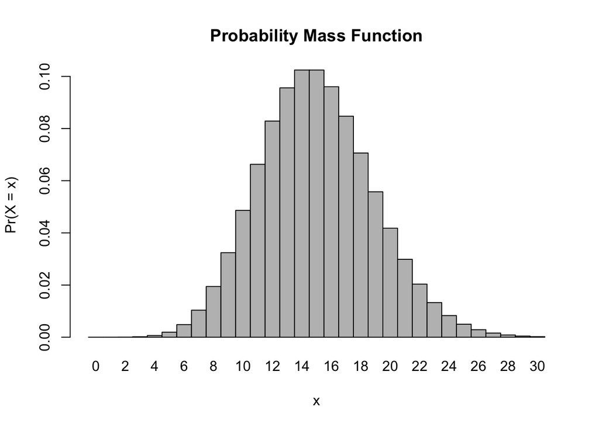

```r
x=0:30
barplot(dpois(x=0:30, lambda = 15), names.arg = x, space = 0, xlab = "x", ylab = "Pr(X = x)", main = "Probability Mass Function")
```

then the CDF

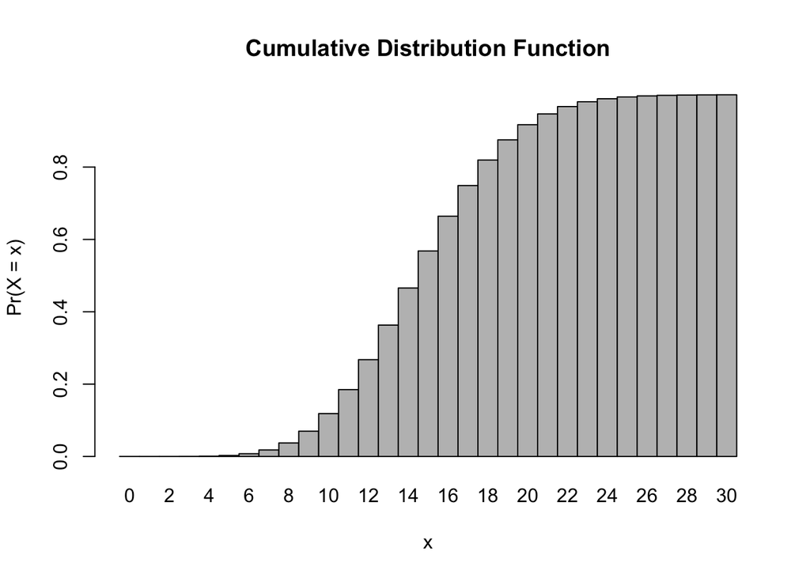

```r
x=0:30
barplot(ppois(q= 0:30, lambda = 15), names.arg = x, space = 0, xlab = "x", ylab = "Pr(X = x)", main = "Cumulative Distribution Function")
```

*Simulate 104 results from this distribution (i.e., 2 years of Saturday monitoring sessions).*

```r
simulation=rpois(104,15)
simulation
```

```
##   [1] 17 15 13 19 18 15 15 12 15 16 15 13 16 18 16 24 12 11 17 17 14 14 22
##  [24] 18 21 18 10 18 14 12 17 12 15 11 21 16 11 18 21 17 15 24 16 13  9 21
##  [47] 14 11 14 10  8 10 13 21 11 17 18  9  8 11 16 25 18 19 23 18 17 14 19
##  [70] 16 16 16 20 14  8 13  8  9 13 15 14 19  9  8 20 26  8 14 10 15 16 11
##  [93] 15 21 20 15 17 18 14 13 14 17 12 11
```

*Plot the simulated results using hist() and use xlim() to set the horizontal limits to be from 0 to 30. How does your histogram compare to the shape of the probability mass function you plotted above?*

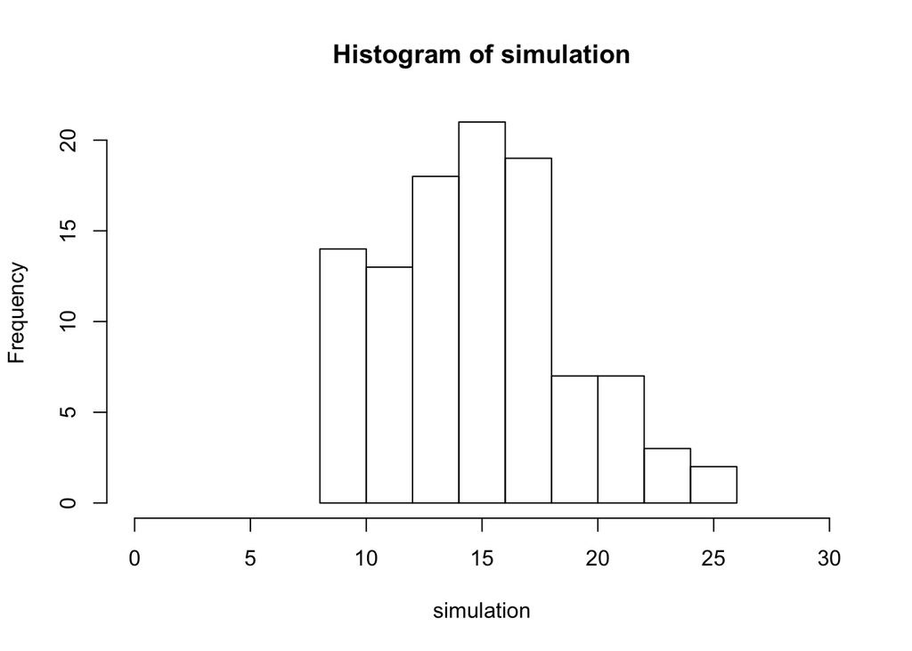

```r
hist(simulation, xlim = c(0,30))
```

These are now just count data of the number of times that the observer heard that many calls over the time period. Before, it was the probability of hearing that many calls during ONE observation. Also, before the values all added up to 1, whereas here, that is no longer the case!